# Results

Sebastian Schuster

6/4/2017

```
##
## This data.table install has not detected OpenMP support. It will work but slower in single threaded mode.
```

```r
# Read the data.
data <- read.csv("../data/data-combined.csv")
```

In my experiment, I am trying to evaluate whether speakers have a bias towards the scope-isomorphic order of determiners, adjectives, numerals, and nouns in an artificial language learning experiment. Participants learn during the training session that this artificial language has post-nominal modifiers but they do not learn the order of the nominal modifiers.

During training, participants hear two different combinations: `NOUN` + `MODIFIER 1` and `NOUN` + `MODIFIER 2`. Modifier 1 and modifier 2 are as following, depending on the condition:

- Condition 1: Numeral, adjective
- Condition 2: Adjective, demonstrative determiner
- Condition 3: Numeral, demonstrative determiner

During the test phase, participants are asked to “translate” phrases with one modifier (as they heard during training – these are control trials) and phrases with two modifiers. As they never observed a noun with two modifiers during training, they have to come up with some strategy on how to order the nominal modifiers.

# Control trials

I first plot the ratio of post-nominal control trials for each of 96 participants. Culbertson and Adger exluded participants who consistenly failed at these trials. While they are not specific about what “consistent” means, I also exlude participants who selected a phrase with a post-nominal modifier in less than 50% of the cases (highlighted in red).

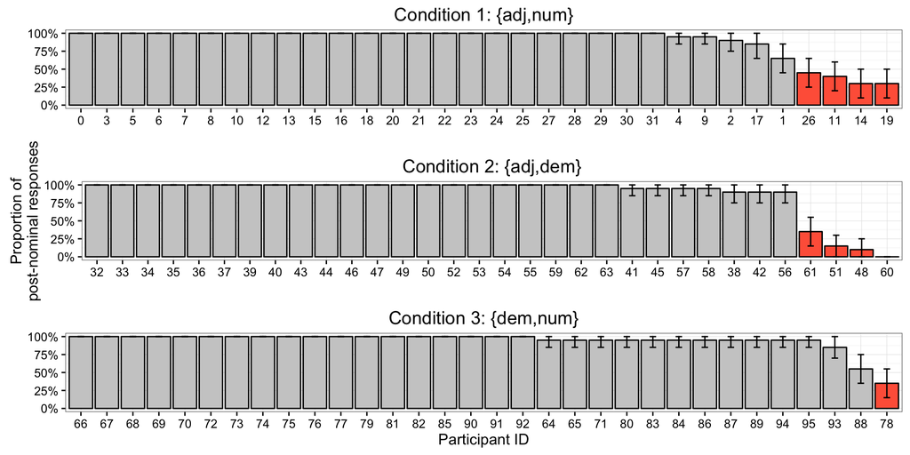

```r
agr.test_control = data %>%
  filter(train == FALSE) %>%
  filter(is.na(modifier2)) %>%
  group_by(condition, workerid) %>%
  summarise(MeanCorrect = mean(correct), CI.Low = ci.low(correct), CI.High = ci.high(correct)) %>%
  mutate(YMin = MeanCorrect - CI.Low, YMax = MeanCorrect + CI.High) %>%
  arrange(condition, desc(MeanCorrect))


agr.test_control$exclude = "1"

agr.test_control[agr.test_control$MeanCorrect < 0.5, ]$exclude = "2"

worker_ids.cond1 = agr.test_control[agr.test_control$condition == 1,]$workerid;
worker_ids.cond2 = agr.test_control[agr.test_control$condition == 2,]$workerid;
worker_ids.cond3 = agr.test_control[agr.test_control$condition == 3,]$workerid;


p1 <- ggplot(agr.test_control[agr.test_control$condition == 1,], aes(x=as.character(workerid), y=MeanCorrect)) +
  geom_bar(stat="identity",color="black", aes(fill=exclude)) +
  scale_fill_manual(values=c("gray80", "tomato1")) +
  geom_errorbar(aes(ymin=YMin,ymax=YMax), width=.25) +
  xlab("") +
  ylab("") +
  ggtitle("Condition 1: {adj,num}") +
  scale_y_continuous(labels=percent) +
  scale_x_discrete(limits= as.character(worker_ids.cond1)) +
  #facet_wrap(~condition, ncol=1, scales = "free") +
  theme(legend.position="none")

p2 <- ggplot(agr.test_control[agr.test_control$condition == 2,], aes(x=as.character(workerid), y=MeanCorrect)) +
  geom_bar(stat="identity",color="black", aes(fill=exclude)) +
  scale_fill_manual(values=c("gray80", "tomato1")) +
  geom_errorbar(aes(ymin=YMin,ymax=YMax), width=.25) +
  xlab("") +
  ylab("Proportion of\npost-nominal responses") +
  scale_y_continuous(labels=percent) +
  scale_x_discrete(limits= as.character(worker_ids.cond2)) +
  ggtitle("Condition 2: {adj,dem}") +
  theme(legend.position="none")

p3 <- ggplot(agr.test_control[agr.test_control$condition == 3,], aes(x=as.character(workerid), y=MeanCorrect)) +
  geom_bar(stat="identity",color="black", aes(fill=exclude)) +
  scale_fill_manual(values=c("gray80", "tomato1")) +
  geom_errorbar(aes(ymin=YMin,ymax=YMax), width=.25) +
  xlab("Participant ID") +
  ylab("") +
  scale_y_continuous(labels=percent) +
  scale_x_discrete(limits= as.character(worker_ids.cond3)) +
  ggtitle("Condition 3: {dem,num}") +
  theme(legend.position="none")



combined_plot <- grid.arrange(p1, p2, p3)
```

```r
ggsave(filename = "plots/participant-performance-control-trial.pdf", plot=combined_plot, width=10, height=5)
```

As this plot shows, 9 of the participants did not meet this threshold and I therefore excluded them from further analyses.

# Test trials

For the test trials, I aggregate all responsed within a condition as in Culbertson and Adger. As the following plot shows, the proportion of isomorphic post-nominal responses (that is noun-adjective-numeral, noun-adjective-determiner, and noun-numeral-determiner, in conditions 1,2, and 3, respectively) is far above chance and has similar values as reported in Culbertson and Adger. However, in my replication there don’t seem to be any (or at least not the same) differences between the three conditions. This is insofar important, as Culbertson and Adger argued based on these differences that participants were not solely inverting the canonical English order. Considering that I was not able to replicate these differences, it might indeed be the case that participants are simply inverting the canonical English order of these phrases, which just happens to be the scope-isomorphic order.

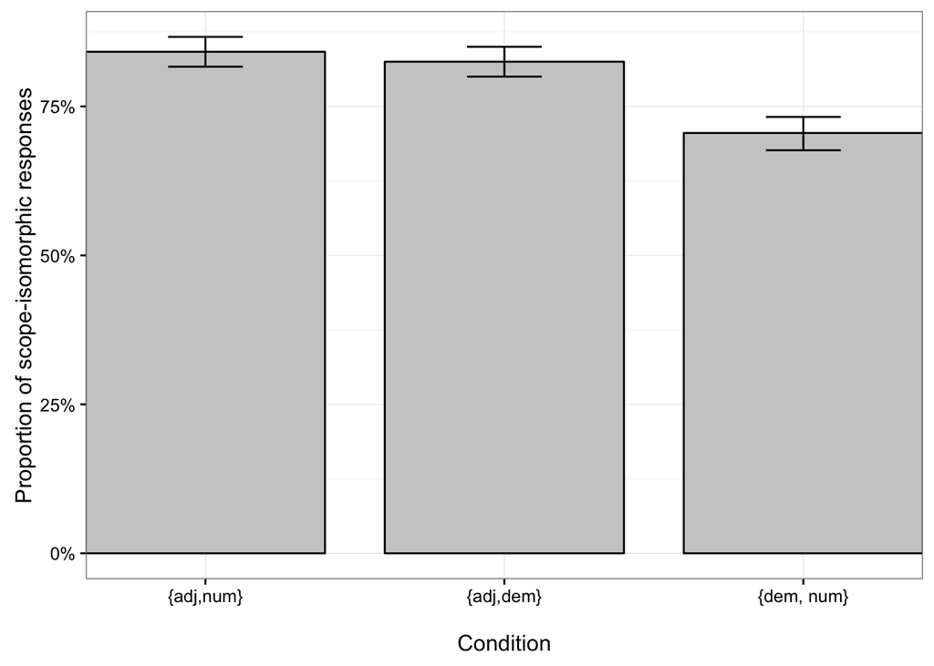

```r
exclude_workers = agr.test_control[agr.test_control$exclude == "2",]$workerid

agr.test = data %>%
  filter((workerid %in% exclude_workers) == FALSE) %>%
  filter(is.na(modifier2) == FALSE) %>%
  group_by(condition) %>%
  summarise(MeanCorrect = mean(correct), CI.Low = ci.low(correct), CI.High = ci.high(correct)) %>%
  mutate(YMin = MeanCorrect - CI.Low, YMax = MeanCorrect + CI.High)

agr.test_indiv = data %>%
  filter((workerid %in% exclude_workers) == FALSE) %>%
  filter(train == FALSE) %>%
  filter(is.na(modifier2) == FALSE) %>%
  group_by(condition, workerid) %>%
  summarise(MeanCorrect = mean(correct), CI.Low = ci.low(correct), CI.High = ci.high(correct)) %>%
  mutate(YMin = MeanCorrect - CI.Low, YMax = MeanCorrect + CI.High) %>%
  arrange(condition, desc(MeanCorrect))


ggplot(agr.test, aes(x=condition,y=MeanCorrect)) +
  geom_bar(stat="identity",fill="gray80",color="black", width=.8) +
  geom_errorbar(aes(ymin=YMin,ymax=YMax), width=.25) +
  xlab("\nCondition") +
  xlim("{adj,num}", "{adj,dem}", "{dem, num}") +
  ylab("Proportion of scope-isomorphic responses") +
  scale_y_continuous(labels=percent)
```

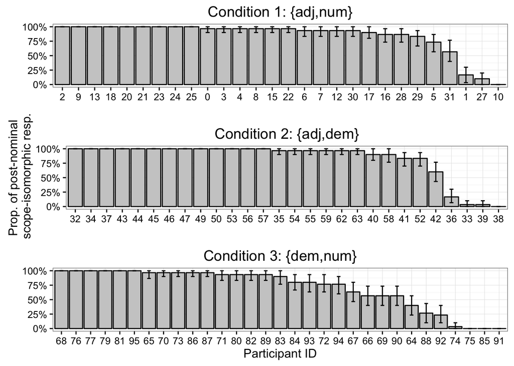

```r
ggsave(filename = "plots/main-results.pdf", width=6, height=6)


worker_ids.cond1 = agr.test_indiv[agr.test_indiv$condition == 1,]$workerid;
worker_ids.cond2 = agr.test_indiv[agr.test_indiv$condition == 2,]$workerid;
worker_ids.cond3 = agr.test_indiv[agr.test_indiv$condition == 3,]$workerid;


p1 <- ggplot(agr.test_indiv[agr.test_indiv$condition == 1,], aes(x=as.character(workerid), y=MeanCorrect)) +
  geom_bar(stat="identity",fill="gray80",color="black") +
  geom_errorbar(aes(ymin=YMin,ymax=YMax), width=.25) +
  xlab("") +
  ylab("") +
  ggtitle("Condition 1: {adj,num}") +
  scale_y_continuous(labels=percent) +
  scale_x_discrete(limits= as.character(worker_ids.cond1)) +
  #facet_wrap(~condition, ncol=1, scales = "free") +
  theme(legend.position="none")

p2 <- ggplot(agr.test_indiv[agr.test_indiv$condition == 2,], aes(x=as.character(workerid), y=MeanCorrect)) +
  geom_bar(stat="identity",fill="gray80",color="black") +
  geom_errorbar(aes(ymin=YMin,ymax=YMax), width=.25) +
  xlab("") +
  ylab("Prop. of post-nominal\n scope-isomorphic resp.") +
  scale_y_continuous(labels=percent) +
  scale_x_discrete(limits= as.character(worker_ids.cond2)) +
  ggtitle("Condition 2: {adj,dem}") +
  theme(legend.position="none")

p3 <- ggplot(agr.test_indiv[agr.test_indiv$condition == 3,], aes(x=as.character(workerid), y=MeanCorrect)) +
  geom_bar(stat="identity",fill="gray80",color="black") +
  geom_errorbar(aes(ymin=YMin,ymax=YMax), width=.25) +
  xlab("Participant ID") +
  ylab("") +
  scale_y_continuous(labels=percent) +
  scale_x_discrete(limits= as.character(worker_ids.cond3)) +
  ggtitle("Condition 3: {dem,num}") +
  theme(legend.position="none")

combined_plot <- grid.arrange(p1, p2, p3)
```

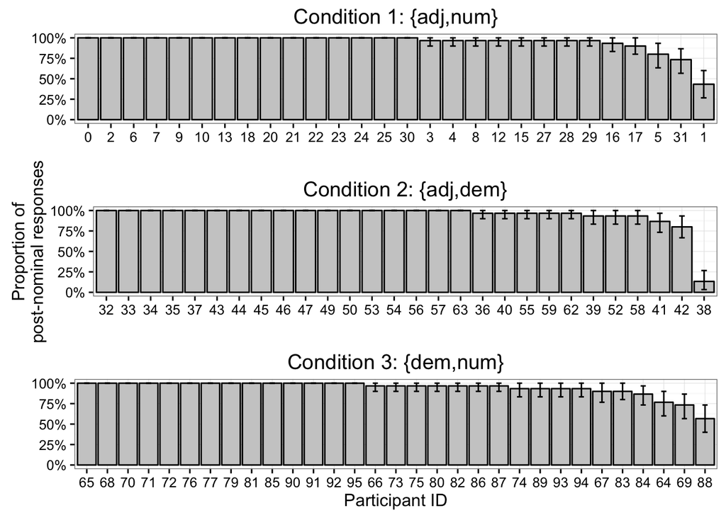

```r
ggsave(filename = "plots/participant-performance-test-trial.pdf", plot=combined_plot, width=10, height=5)


#same plot with proportion of post-nominal

agr.test_indiv = data %>%
  filter((workerid %in% exclude_workers) == FALSE) %>%
  filter(train == FALSE) %>%
  filter(is.na(modifier2) == FALSE) %>%
  group_by(condition, workerid) %>%
  summarise(MeanCorrect = mean(post_nominal), CI.Low = ci.low(post_nominal), CI.High = ci.high(post_nominal)) %>%
  mutate(YMin = MeanCorrect - CI.Low, YMax = MeanCorrect + CI.High) %>%
  arrange(condition, desc(MeanCorrect))

worker_ids.cond1 = agr.test_indiv[agr.test_indiv$condition == 1,]$workerid;
worker_ids.cond2 = agr.test_indiv[agr.test_indiv$condition == 2,]$workerid;
worker_ids.cond3 = agr.test_indiv[agr.test_indiv$condition == 3,]$workerid;


p1 <- ggplot(agr.test_indiv[agr.test_indiv$condition == 1,], aes(x=as.character(workerid), y=MeanCorrect)) +
  geom_bar(stat="identity",fill="gray80",color="black") +
  geom_errorbar(aes(ymin=YMin,ymax=YMax), width=.25) +
  xlab("") +
  ylab("") +
  ggtitle("Condition 1: {adj,num}") +
  scale_y_continuous(labels=percent) +
  scale_x_discrete(limits= as.character(worker_ids.cond1)) +
  #facet_wrap(~condition, ncol=1, scales = "free") +
  theme(legend.position="none")

p2 <- ggplot(agr.test_indiv[agr.test_indiv$condition == 2,], aes(x=as.character(workerid), y=MeanCorrect)) +
  geom_bar(stat="identity",fill="gray80",color="black") +
  geom_errorbar(aes(ymin=YMin,ymax=YMax), width=.25) +
  xlab("") +
  ylab("Proportion of\npost-nominal responses") +
  scale_y_continuous(labels=percent) +
  scale_x_discrete(limits= as.character(worker_ids.cond2)) +
  ggtitle("Condition 2: {adj,dem}") +
  theme(legend.position="none")

p3 <- ggplot(agr.test_indiv[agr.test_indiv$condition == 3,], aes(x=as.character(workerid), y=MeanCorrect)) +
  geom_bar(stat="identity",fill="gray80",color="black") +
  geom_errorbar(aes(ymin=YMin,ymax=YMax), width=.25) +
  xlab("Participant ID") +
  ylab("") +
  scale_y_continuous(labels=percent) +
  scale_x_discrete(limits= as.character(worker_ids.cond3)) +
  ggtitle("Condition 3: {dem,num}") +
  theme(legend.position="none")

grid.arrange(p1, p2, p3)
```

# Analysis

The statistical model decription in Culbertson and Adger is very superficial, so I was not able to reconstruct exaclty what they did. They state that they used a Bayesian mixed-effects logistic regression model with random subject and item intercepts but from their description it is not entirely clear what they modelled as fixed effects and what exactly their dependent variable was.

As I did not see a huge advantage of using a Bayesian model for this analysis, I used a generalized linear model. My dependent variable is whether participants chose the post-nominal scope-isomorphic ordering (`1`) or another ordering (`0`). I only used the condition as a fixed effect (using dummy coding with condition 1 as the reference condition). I excluded the data from 9 participants as explained in the section above.

```r
data.test = data %>%
  filter((workerid %in% exclude_workers) == FALSE)  %>%
  filter(is.na(modifier2) == FALSE)

data.test$condition = factor(data.test$condition)

#just fixed effect
model1 <- glm(correct ~ condition, family="binomial", data = data.test)
res1 <- summary(model1)
print(res1)
```

```
##
## Call:
## glm(formula = correct ~ condition, family = "binomial", data = data.test)
##
## Deviance Residuals:
##     Min       1Q   Median       3Q      Max
## -1.9199   0.5871   0.6203   0.8355   0.8355
##
## Coefficients:
##             Estimate Std. Error z value Pr(>|z|)
## (Intercept)  1.67068    0.09452  17.676  < 2e-16 ***
## condition2  -0.12008    0.13107  -0.916     0.36
## condition3  -0.79765    0.11877  -6.716 1.87e-11 ***
## ---
## Signif. codes:  0 '***' 0.001 '**' 0.01 '*' 0.05 '.' 0.1 ' ' 1
##
## (Dispersion parameter for binomial family taken to be 1)
##
##     Null deviance: 2698.4  on 2609  degrees of freedom
## Residual deviance: 2640.7  on 2607  degrees of freedom
## AIC: 2646.7
##
## Number of Fisher Scoring iterations: 4
```

However, if we include random intercepts for subjects, this effect goes away (though there remains a marginally significant effect).

```r
#random effects for subjects only
model2 <- glmer(correct ~ condition + (1 | workerid), family="binomial", data=data.test)
res2 <- summary(model2)
print(res2)
```

```
## Generalized linear mixed model fit by maximum likelihood (Laplace
##   Approximation) [glmerMod]
##  Family: binomial  ( logit )
## Formula: correct ~ condition + (1 | workerid)
##    Data: data.test
##
##      AIC      BIC   logLik deviance df.resid
##   1382.7   1406.1   -687.3   1374.7     2606
##
## Scaled residuals:
##     Min      1Q  Median      3Q     Max
## -5.4732  0.0711  0.0980  0.2629  4.4387
##
## Random effects:
##  Groups   Name        Variance Std.Dev.
##  workerid (Intercept) 10.38    3.222
## Number of obs: 2610, groups:  workerid, 87
##
## Fixed effects:
##             Estimate Std. Error z value Pr(>|z|)
## (Intercept)   3.2983     0.6952   4.744 2.09e-06 ***
## condition2    0.4220     0.9889   0.427    0.670
## condition3   -1.6156     0.9258  -1.745    0.081 .
## ---
## Signif. codes:  0 '***' 0.001 '**' 0.01 '*' 0.05 '.' 0.1 ' ' 1
##
## Correlation of Fixed Effects:
##            (Intr) cndtn2
## condition2 -0.659
## condition3 -0.741  0.500
```

```r
lrtest(model1, model2)
```

```
## Likelihood ratio test
##
## Model 1: correct ~ condition
## Model 2: correct ~ condition + (1 | workerid)
##   #Df   LogLik Df Chisq Pr(>Chisq)
## 1   3 -1320.33
## 2   4  -687.33  1  1266  < 2.2e-16 ***
## ---
## Signif. codes:  0 '***' 0.001 '**' 0.01 '*' 0.05 '.' 0.1 ' ' 1
```

Considering that this model fits the data significantly better than the fixed-effects model according to a likelihood ratio test ($\chi^2(1)=1266$, $p<0.001$), it seems as if the difference between conditions 1 and 3 is a random artifact of certain subjects rather than an actual effect.

Further, I include random item intercepts in my model.

```r
#random effects for subjects and items
model3 <- glmer(correct ~ condition + (1 | workerid) + (1 | stimulus), family="binomial", data=data.test)
summary(model3)
```

```
## Generalized linear mixed model fit by maximum likelihood (Laplace
##   Approximation) [glmerMod]
##  Family: binomial  ( logit )
## Formula: correct ~ condition + (1 | workerid) + (1 | stimulus)
##    Data: data.test
##
##      AIC      BIC   logLik deviance df.resid
##   1384.7   1414.0   -687.3   1374.7     2605
##
## Scaled residuals:
##     Min      1Q  Median      3Q     Max
## -5.4732  0.0711  0.0980  0.2629  4.4387
##
## Random effects:
##  Groups   Name        Variance Std.Dev.
##  stimulus (Intercept)  0.00    0.000
##  workerid (Intercept) 10.38    3.222
## Number of obs: 2610, groups:  stimulus, 1737; workerid, 87
##
## Fixed effects:
##             Estimate Std. Error z value Pr(>|z|)
## (Intercept)   3.2983     0.6947   4.748 2.05e-06 ***
## condition2    0.4220     0.9886   0.427   0.6695
## condition3   -1.6156     0.9248  -1.747   0.0807 .
## ---
## Signif. codes:  0 '***' 0.001 '**' 0.01 '*' 0.05 '.' 0.1 ' ' 1
##
## Correlation of Fixed Effects:
##            (Intr) cndtn2
## condition2 -0.659
## condition3 -0.740  0.499
```

```r
lrtest(model2, model3)
```

```
## Likelihood ratio test
##
## Model 1: correct ~ condition + (1 | workerid)
## Model 2: correct ~ condition + (1 | workerid) + (1 | stimulus)
##   #Df  LogLik Df Chisq Pr(>Chisq)
## 1   4 -687.33
## 2   5 -687.33  1     0     0.9996
```

As there are 1737 different stimuli as part of 2610 observations, the per-item estimates are most likely not reliable. And even if they are, the model does not fit the data significantly better than the model that only contains per-subject random intercepts, I therefore use the model with condition as a fixed effect and random subject intercepts as my final model.

Lastly, I analyze whether the proportion of post-nominal scope-isomorphic ordered translations selected by participants is above chance. As my second model shows, the intercept is significantly above $0$ ($b=3.3$, $z=4.74$, $p<0.001$). Across all conditions, participants therefore selected the post-nominal scope-isomorphic order significantly more often than expected by chance. As expected, this also holds, if we compute the intercept for each individual condition, as shown in the following three models.

```r
# Condition 1
model2.1 <- glmer(correct ~ 1 + (1 | workerid), family="binomial", data=data.test[data.test$condition==1,])
summary(model2.1)
```

```
## Generalized linear mixed model fit by maximum likelihood (Laplace
##   Approximation) [glmerMod]
##  Family: binomial  ( logit )
## Formula: correct ~ 1 + (1 | workerid)
##    Data: data.test[data.test$condition == 1, ]
##
##      AIC      BIC   logLik deviance df.resid
##    418.1    427.6   -207.0    414.1      838
##
## Scaled residuals:
##     Min      1Q  Median      3Q     Max
## -5.2914  0.0903  0.1890  0.2630  2.6622
##
## Random effects:
##  Groups   Name        Variance Std.Dev.
##  workerid (Intercept) 7.11     2.666
## Number of obs: 840, groups:  workerid, 28
##
## Fixed effects:
##             Estimate Std. Error z value Pr(>|z|)
## (Intercept)   3.0867     0.5991   5.153 2.57e-07 ***
## ---
## Signif. codes:  0 '***' 0.001 '**' 0.01 '*' 0.05 '.' 0.1 ' ' 1
```

```r
# Condition 2
model2.2 <- glmer(correct ~ 1 + (1 | workerid), family="binomial", data=data.test[data.test$condition==2,])
summary(model2.2)
```

```
## Generalized linear mixed model fit by maximum likelihood (Laplace
##   Approximation) [glmerMod]
##  Family: binomial  ( logit )
## Formula: correct ~ 1 + (1 | workerid)
##    Data: data.test[data.test$condition == 2, ]
##
##      AIC      BIC   logLik deviance df.resid
##    317.7    327.1   -156.8    313.7      838
##
## Scaled residuals:
##     Min      1Q  Median      3Q     Max
## -5.5505  0.0519  0.0519  0.1802  4.4985
##
## Random effects:
##  Groups   Name        Variance Std.Dev.
##  workerid (Intercept) 18.09    4.253
## Number of obs: 840, groups:  workerid, 28
##
## Fixed effects:
##              Estimate Std. Error z value Pr(>|z|)
## (Intercept) 4.4556945  0.0008324    5353   <2e-16 ***
## ---
## Signif. codes:  0 '***' 0.001 '**' 0.01 '*' 0.05 '.' 0.1 ' ' 1
## convergence code: 0
## Model failed to converge with max|grad| = 0.0848938 (tol = 0.001, component 1)
## Model is nearly unidentifiable: very large eigenvalue
##  - Rescale variables?
```

```r
# Condition 3
model2.3 <- glmer(correct ~ 1 + (1 | workerid), family="binomial", data=data.test[data.test$condition==3,])
summary(model2.3)
```

```
## Generalized linear mixed model fit by maximum likelihood (Laplace
##   Approximation) [glmerMod]
##  Family: binomial  ( logit )
## Formula: correct ~ 1 + (1 | workerid)
##    Data: data.test[data.test$condition == 3, ]
##
##      AIC      BIC   logLik deviance df.resid
##    648.7    658.3   -322.3    644.7      928
##
## Scaled residuals:
##     Min      1Q  Median      3Q     Max
## -4.9798 -0.1408  0.2008  0.2742  4.3860
##
## Random effects:
##  Groups   Name        Variance Std.Dev.
##  workerid (Intercept) 9.558    3.092
## Number of obs: 930, groups:  workerid, 31
##
## Fixed effects:
##             Estimate Std. Error z value Pr(>|z|)
## (Intercept)   1.6542     0.5819   2.842  0.00448 **
## ---
## Signif. codes:  0 '***' 0.001 '**' 0.01 '*' 0.05 '.' 0.1 ' ' 1
```

# (Brief) Discussion

I was able to reproduce the effect that participants selected the post-nominal scope-isomorphic order significantly more often than chance. However, I failed to reproduce the effect of scope distance on the selection of post-nominal scope-isomorphic orders – in all three conditions participants were equally likely to choose this order. While this does not provide any evidence against the hypothesis that subjects prefer scope-isomorphic orders, this result might suggest that participants are just reversing the English order after all. Culbertson and Adger (2014) used the differences across conditions to argue against this explanation; they rightly pointed out that if people were simply reversing the English order then we would not expect any differences across conditions. However, considering that I was not able to reproduce this effect, it might as well just be that the majority of participants uses a strategy that does not linked to the the scope of nominal modifiers.